# Dolcetto Screens analyses

in following lines whole geneome CRISPRi drop-out screen was conducted using Dolcetto library

Fiaj-1 dCas9-KRAB-MeCP2, Monoclone Q2.2

Fiaj-1 dCas9-KRAB-MeCP2,Polyclone

Kolf2-ARID1A-KO-WT-dCas9-KRAB-MeCP2,M2

Kolf2-ARID1A-KO-WT-dCas9-KRAB-MeCP2,M5

Kolf2-ARID1A-KO-Het1-dCas9-KRAB-MeCP2,M5

K562-dCas9-KRAB-MeCP2, Monoclone

also CRISPRi screens are compared to CRISPR screens in Fiaj1 line (Peets et al, 2019) Rosetta file contains all data to relate screen numbers to relevant metadata

### Analysis of Dolcetto Library

Dolcetto library reference is downloaded from website of Broad Institute Genetic Perturbation Platform: https://portals.broadinstitute.org/gpp/public/resources/protocols

annotations are according to GCHR38

```r
setwd("E:/Paper writing/CRIPSRi paper/Analyses/Dolcetto_screen_analyses/publication/publication_final")
library(tidyverse)
library(ggsci)
library(reshape2)
```

```r
library(ineq)
library(ggpubr)
library(cowplot)
library(pROC)
library(svglite)
```

```r
theme_su<-  function(){
  font <- "Arial"   #assign font family up front

  theme_bw() %+replace%    #replace elements we want to change

    theme(


      #text elements
      plot.title = element_text(             #title
        family = "Arial",            #set font family
        size = 8,                #set font size
        face = 'bold',            #bold typeface
        hjust = 0,                #left align
        vjust = 3),               #raise slightly

      plot.subtitle = element_text(          #subtitle
        family = "Arial",            #font family
        size = 6),               #font size

      plot.caption = element_text(           #caption
        family = "Arial",            #font family
        size = 6,                 #font size
        hjust = 1),               #right align

      axis.title = element_text(             #axis titles
        family = "Arial",

        size = 6),               #font size

      axis.text = element_text(              #axis text
        family = "Arial",            #axis famuly
        size = 6),                #font size

      axis.text.x = element_text(            #margin for axis text
        margin=margin(5, b = 10)),

     legend.title=element_text(
       family="Arial",
       size=8,
       hjust = 0),
     legend.text=element_text(
       family = "Arial",
       size=6),

     panel.grid.major = element_blank(),
     panel.grid.minor = element_blank()
     )



}
```

```r
Dolcetto_reference_GCHR38 <- read.csv("input/Dolcetto_reference_GCHR38.txt")
names(Dolcetto_reference_GCHR38)
```

```
## [1] "X"       "grna_id" "seq_20"  "seq_19"  "region"  "start"   "end"
## [8] "strand"
```

```r
print(paste("there are", NROW(unique(Dolcetto_reference_GCHR38$grna_id)), "unique guides in Dolcetto Library, targeting", NROW(Dolcetto_reference_GCHR38), "regions in the genome"))
```

```
## [1] "there are 56554 unique guides in Dolcetto Library, targeting 187507 regions in the genome"
```

```r
nTargets<- as.data.frame(table(Dolcetto_reference_GCHR38$grna_id))
distribution_of_target_number<- as.data.frame(table(nTargets$Freq)) %>% rename("Target_number"=Var1, "Count"=Freq)
distribution_of_target_number
```

| Target_number | Count |
| --- | --- |
| 1 | 55388 |
| 2 | 726 |
| 3 | 229 |
| 4 | 90 |
| 5 | 25 |
| 6 | 15 |
| 7 | 7 |
| 8 | 13 |
| 9 | 8 |
| 10 | 8 |

[output cut: 30 more lines]

assign target locus count to reference data

```r
nTargets<- nTargets %>% rename(grna_id=Var1, nLoci=Freq)

Dolcetto_reference_GCHR38<- left_join(Dolcetto_reference_GCHR38, nTargets, by="grna_id")
Dolcetto_reference_GCHR38<- Dolcetto_reference_GCHR38 %>% mutate(Unique= case_when(
  nLoci >1 ~"Non_unique",
  nLoci ==1 ~"Unique"
))
print(paste("There are", NROW(Dolcetto_reference_GCHR38 %>% filter(Unique=="Unique")),"unique guides in Dolcetto Library and", NROW(unique(Dolcetto_reference_GCHR38 %>% filter(Unique=="Non_unique") %>% select(grna_id))),"guides targets more than one locus"))
```

```
## [1] "There are 55388 unique guides in Dolcetto Library and 1166 guides targets more than one locus"
```

```r
all_dolcetto_reads_curated<-read_tsv( file="input/all_dolcetto_curated_reads.txt")
names(all_dolcetto_reads_curated)
```

```
##   [1] "Guide.Sequence"    "Gene"              "func"
##   [4] "DOL.1"             "DOL.2"             "DOL.3"
##   [7] "DOL.V2"            "Dol.V3"            "DOL_V3_1"
##  [10] "DOL_V3_2"          "DOL_V3_3"          "DOLCETTO"
##  [13] "D1M_D14"           "D1M_D18"           "D1M_D9"
##  [16] "D1P_D14"           "D1P_D18"           "D1P_D22"
##  [19] "K562_D14"          "K562_D18"          "K562_D21"
##  [22] "D1M1R1_D14"        "D1M1R1_D18"        "D1M1R1_D5"
##  [25] "D1M1R1_D9"         "D1M1R2_D14"        "D1M1R2_D18"
##  [28] "D1M1R3_D14"        "D1M1R3_D18"        "D1M1R3_D5"
##  [31] "D1M1R3_D9"         "D1M1R4_D14"        "D1M1R4_D18"
##  [34] "D1M1_All_D14"      "D1M1_All_D18"      "D1M1_All_D9"
##  [37] "D2M1R02_Cont"      "D2M1R02_Noc"       "D2M1R1_D15"
##  [40] "D2M1R1_D21"        "D2M1R2_D15"        "D2M1R2_D21"
##  [43] "D2M1_All_D15"      "D2M1_All_D21"      "ARID1A_HT_R1_D13"
```

[output cut: 21 more lines]

```r
all_dolcetto_reads_curated<- do.call("data.frame", all_dolcetto_reads_curated)
```

calculate coverage for each screen:

```r
summary<- as.data.frame(summary(all_dolcetto_reads_curated[4:106])) %>% separate(Freq, sep=":", into=c("Variable","Value" )) %>% select(Screen=Var2, Variable, Value)
library(reshape2)
summary<- as.data.frame(summary %>% acast(Screen~Variable))
summary$screens<- rownames(summary)
summary<- do.call(data.frame, summary)
summary$screens<- as.factor(summary$screens)
write_csv(summary, file = "output/supplemantary_table_screen_raw_Reads_summanry.txt")

summary
```

|  | X1st.Qu. | X3rd.Qu. | Max.... | Mean... | Median. | Min.... | screens |
| --- | --- | --- | --- | --- | --- | --- | --- |
| DOL.1 | 120 | 222 | 762 | 176 | 166 | 0 | DOL.1 |
| DOL.2 | 181.0 | 336.0 | 1217.0 | 265.4 | 251.0 | 0.0 | DOL.2 |
| DOL.3 | 130.0 | 240.0 | 825.0 | 190.3 | 180.0 | 0.0 | DOL.3 |
| DOL.V2 | 433.0 | 797.0 | 2804.0 | 631.7 | 598.0 | 0.0 | DOL.V2 |
| Dol.V3 | 752 | 1496 | 41161 | 1168 | 1086 | 0 | Dol.V3 |
| DOL_V3_1 | 165.0 | 370.0 | 10135.0 | 280.4 | 257.0 | 0.0 | DOL_V3_1 |
| DOL_V3_2 | 203.0 | 455.0 | 12526.0 | 346.1 | 317.0 | 0.0 | DOL_V3_2 |
| DOL_V3_3 | 320.0 | 711.0 | 18500.0 | 541.2 | 496.0 | 0.0 | DOL_V3_3 |
| DOLCETTO | 307.0 | 568.0 | 2053.0 | 450.6 | 426.0 | 0.0 | DOLCETTO |
| D1M_D14 | 280.0 | 942.0 | 5583.0 | 651.1 | 618.0 | 0.0 | D1M_D14 |

[output cut: 93 more lines]

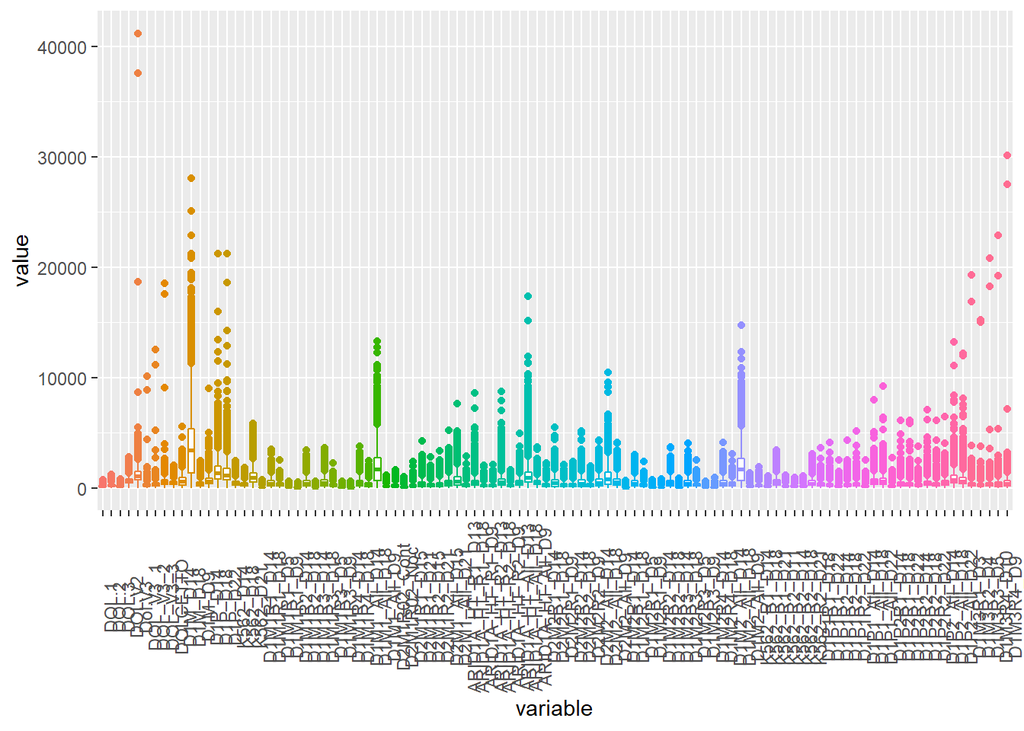

```r
a<- melt(all_dolcetto_reads_curated,id.vars = 1:3,measure.vars = 4:106)
a %>% ggplot(aes(y=value, x=variable, color=variable)) + geom_boxplot()+theme(legend.position = "none", axis.text.x =element_text(angle=90))
```

```r
column_sum<-as.data.frame(colSums(all_dolcetto_reads_curated[,4:106]))
column_sum<- column_sum %>% mutate(screens= rownames(column_sum)) %>% mutate(coverage=round((column_sum[,1]/57042),0))
coverage<- column_sum %>% select(2,3)
coverage<- do.call(data.frame, coverage)
references<- c("DOL.1", "DOL.2","DOL.3","DOL.V2", "DOLCETTO", "Dol.V3","DOL_V3_1","DOL_V3_2", "DOL_V3_3")


levels(coverage$screens)
```

```
##   [1] "ARID1A_HT_All_D13" "ARID1A_HT_All_D18" "ARID1A_HT_All_D9"
##   [4] "ARID1A_HT_R1_D13"  "ARID1A_HT_R1_D18"  "ARID1A_HT_R1_D9"
##   [7] "ARID1A_HT_R2_D13"  "ARID1A_HT_R2_D18"  "ARID1A_HT_R2_D9"
##  [10] "D1M_D14"           "D1M_D18"           "D1M_D9"
##  [13] "D1M1_All_D14"      "D1M1_All_D18"      "D1M1_All_D9"
##  [16] "D1M1R1_D14"        "D1M1R1_D18"        "D1M1R1_D5"
##  [19] "D1M1R1_D9"         "D1M1R2_D14"        "D1M1R2_D18"
##  [22] "D1M1R3_D14"        "D1M1R3_D18"        "D1M1R3_D5"
##  [25] "D1M1R3_D9"         "D1M1R4_D14"        "D1M1R4_D18"
##  [28] "D1M2_All_D14"      "D1M2_All_D18"      "D1M2_All_D9"
##  [31] "D1M2R1_D14"        "D1M2R1_D18"        "D1M2R1_D5"
##  [34] "D1M2R1_D9"         "D1M2R2_D14"        "D1M2R2_D18"
##  [37] "D1M2R3_D14"        "D1M2R3_D18"        "D1M2R3_D5"
##  [40] "D1M2R3_D9"         "D1M2R4_D14"        "D1M2R4_D18"
##  [43] "D1M3R1_D3"         "D1M3R2_D4"         "D1M3R3_D5"
```

[output cut: 20 more lines]

```r
a<- coverage %>% filter(!(screens %in% references))
a<- a %>% mutate(new=screens)
a<- a %>% separate(new, sep="_D", into=c("screen_name", "Time_Point"))
a<- do.call("data.frame",a)

levels(a$Time_Point)
```

```
##  [1] "10" "11" "13" "14" "15" "18" "21" "22" "3"  "4"  "5"  "9"
```

[output not shown]

[output cut: 163 more lines]

[output not shown]

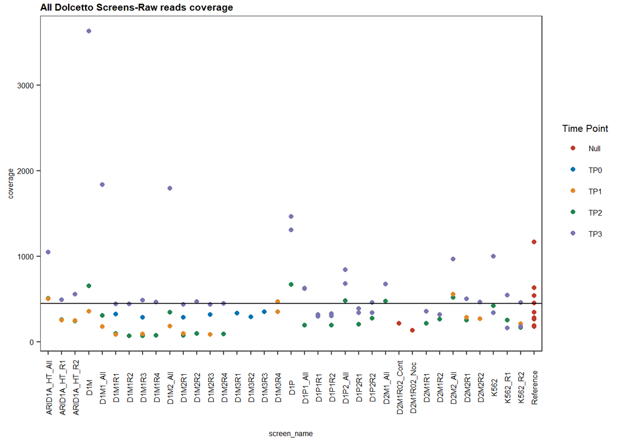

```r
a<- a %>% mutate(TP=case_when(
  Time_Point %in% c(3,4,5)~ "TP0",
  Time_Point %in% c(9,10,11)~ "TP1",
  Time_Point %in% c(13,14,15)~ "TP2",
  Time_Point %in% c(18,21,22)~ "TP3"))
coverage<- left_join(coverage,a, by="screens")
coverage<- coverage %>% mutate(screen_name=case_when(
  screens %in% references  ~"Reference",
  TRUE ~ as.character(screen_name)))


coverage<- coverage %>% select(screens, coverage=coverage.x, screen_name, Time_Point, TP)
coverage$TP[is.na(coverage$TP)]<- "Null"

supp_fig_3_a<- coverage %>% ggplot(aes(x=screen_name, y=coverage, color=TP))+geom_point()+theme_su()+theme(axis.text.x = element_text(angle = 90, size=6))+geom_hline(yintercept = mean(coverage$coverage))+scale_color_nejm(name="Time Point")+ggtitle("All Dolcetto Screens-Raw reads coverage")
supp_fig_3_a
```

```r
ggsave(supp_fig_3_a, filename = "E:/Paper writing/CRIPSRi paper/Analyses/plots/panel_3/supp_fig_3_a.svg", width = 5, height = 3, units = "in", dpi = 1000)

print(paste("average coverage of screens is", round(mean(coverage$coverage),0), "with maximum coverage of", round(max(coverage$coverage),0)))
```

```
## [1] "average coverage of screens is 445 with maximum coverage of 3632"
```

final time points are sequenced targeting 500X coverage, interval time points target coverage was 125X, when reads for all replicates are summed together we obtain ~3600X for IPSC monoclonal screens.

### uniformity of plasmid library distribution and Gini index

Gini index measures the equality of distribution within a population. it is used to measure if distribution of guides within a library is skewed or not. Values between 0-0.2 means perfect equality and 0.2-0.4 denotes equality

```r
reference_reads<- all_dolcetto_reads_curated %>% select(references)
```

```
## Note: Using an external vector in selections is ambiguous.
## i Use `all_of(references)` instead of `references` to silence this message.
## i See <https://tidyselect.r-lib.org/reference/faq-external-vector.html>.
```

```r
reference_reads_melted<- reference_reads %>% melt()
```

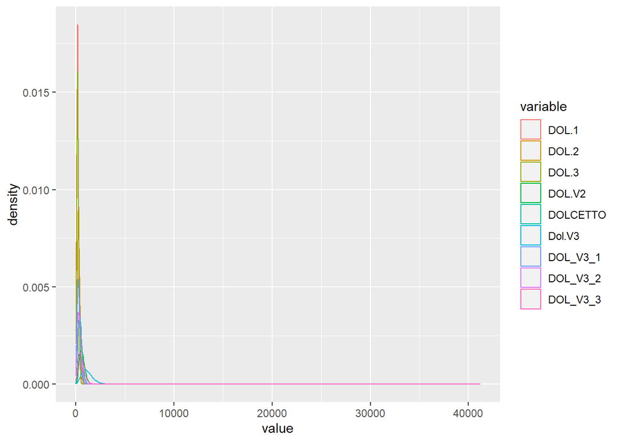

```r
reference_reads_melted %>% ggplot(aes(x=value, color=variable))+geom_density()
```

```r
##calculate gini index and other features of the libraries

gini_values<- as.data.frame(names(reference_reads))
names(gini_values)<- c("Library")
index<- c(1:ncol(reference_reads))
for (i in index) {
  gini_values[i,"gini_index"]<-ineq(reference_reads[,i])
  gini_values[i,"Zero_reads"]<-nrow(reference_reads %>% filter(reference_reads[,i]==0))
  gini_values[i,"x<16"]<-nrow(reference_reads %>% filter(reference_reads[,i]< 16))
  gini_values[i,"max"]<-max(reference_reads[,i])
  gini_values[i,"median"]<-median(reference_reads[,i])
  gini_values[i,"mean"]<-mean(reference_reads[,i])
}
gini_values
```

| Library | gini_index | Zero_reads | x<16 | max | median | mean |
| --- | --- | --- | --- | --- | --- | --- |
| DOL.1 | 0.2469704 | 32 | 130 | 762 | 166 | 175.9707 |
| DOL.2 | 0.2455618 | 30 | 93 | 1217 | 251 | 265.4198 |
| DOL.3 | 0.2468182 | 31 | 134 | 825 | 180 | 190.3182 |
| DOL.V2 | 0.2424225 | 27 | 44 | 2804 | 598 | 631.7087 |
| DOLCETTO | 0.2454532 | 25 | 54 | 2053 | 426 | 450.5902 |
| Dol.V3 | 0.2724571 | 41 | 70 | 41161 | 1086 | 1167.6816 |
| DOL_V3_1 | 0.3083372 | 112 | 409 | 10135 | 257 | 280.4364 |
| DOL_V3_2 | 0.3094668 | 126 | 383 | 12526 | 317 | 346.0528 |
| DOL_V3_3 | 0.3075034 | 103 | 281 | 18500 | 496 | 541.1924 |

```r
write_csv2(gini_values, file = "output/supp_table_2_gini_values.txt")
```

distribution of guides in libraries are not skewed

### LFC calculation

```r
set_1<- all_dolcetto_reads_curated %>% select(Guide.Sequence, Gene,func,reference=DOLCETTO,D1M_D9,D1M_D14, D1M_D18, contains(c("D1M1", "D1M2", "K562")))
names(set_1)
```

```
##  [1] "Guide.Sequence" "Gene"           "func"           "reference"
##  [5] "D1M_D9"         "D1M_D14"        "D1M_D18"        "D1M1R1_D14"
##  [9] "D1M1R1_D18"     "D1M1R1_D5"      "D1M1R1_D9"      "D1M1R2_D14"
## [13] "D1M1R2_D18"     "D1M1R3_D14"     "D1M1R3_D18"     "D1M1R3_D5"
## [17] "D1M1R3_D9"      "D1M1R4_D14"     "D1M1R4_D18"     "D1M1_All_D14"
## [21] "D1M1_All_D18"   "D1M1_All_D9"    "D1M2R1_D14"     "D1M2R1_D18"
## [25] "D1M2R1_D5"      "D1M2R1_D9"      "D1M2R2_D14"     "D1M2R2_D18"
## [29] "D1M2R3_D14"     "D1M2R3_D18"     "D1M2R3_D5"      "D1M2R3_D9"
## [33] "D1M2R4_D14"     "D1M2R4_D18"     "D1M2_All_D14"   "D1M2_All_D18"
## [37] "D1M2_All_D9"    "K562_D14"       "K562_D18"       "K562_D21"
## [41] "K562_R1_D14"    "K562_R1_D18"    "K562_R1_D21"    "K562_R2_D11"
## [45] "K562_R2_D14"    "K562_R2_D18"    "K562_R2_D21"
```

```r
set_2<- all_dolcetto_reads_curated %>% select(Guide.Sequence, Gene,func, reference=DOL.V2, contains(c("D1P", "D2M", "ARID1A")))

set_3<- all_dolcetto_reads_curated %>% select(Guide.Sequence, Gene,func, reference=Dol.V3, contains("D1M3"))
names(set_3)
```

```
## [1] "Guide.Sequence" "Gene"           "func"           "reference"
## [5] "D1M3R1_D3"      "D1M3R2_D4"      "D1M3R3_D5"      "D1M3R4_D10"
## [9] "D1M3R4_D9"
```

### Set 1 LFC

```r
names(set_1)
```

```
##  [1] "Guide.Sequence" "Gene"           "func"           "reference"
##  [5] "D1M_D9"         "D1M_D14"        "D1M_D18"        "D1M1R1_D14"
##  [9] "D1M1R1_D18"     "D1M1R1_D5"      "D1M1R1_D9"      "D1M1R2_D14"
## [13] "D1M1R2_D18"     "D1M1R3_D14"     "D1M1R3_D18"     "D1M1R3_D5"
## [17] "D1M1R3_D9"      "D1M1R4_D14"     "D1M1R4_D18"     "D1M1_All_D14"
## [21] "D1M1_All_D18"   "D1M1_All_D9"    "D1M2R1_D14"     "D1M2R1_D18"
## [25] "D1M2R1_D5"      "D1M2R1_D9"      "D1M2R2_D14"     "D1M2R2_D18"
## [29] "D1M2R3_D14"     "D1M2R3_D18"     "D1M2R3_D5"      "D1M2R3_D9"
## [33] "D1M2R4_D14"     "D1M2R4_D18"     "D1M2_All_D14"   "D1M2_All_D18"
## [37] "D1M2_All_D9"    "K562_D14"       "K562_D18"       "K562_D21"
## [41] "K562_R1_D14"    "K562_R1_D18"    "K562_R1_D21"    "K562_R2_D11"
## [45] "K562_R2_D14"    "K562_R2_D18"    "K562_R2_D21"
```

```r
column_sums_1<- colSums(set_1[4:ncol(set_1)], na.rm = T)

set_1$Log<- log2((sweep(set_1[4:ncol(set_1)], 2, column_sums_1,FUN = "/", check.margin = TRUE))*10^6 +1)
set_1 <- do.call("data.frame",set_1)
names(set_1)
```

```
##  [1] "Guide.Sequence"   "Gene"             "func"             "reference"
##  [5] "D1M_D9"           "D1M_D14"          "D1M_D18"          "D1M1R1_D14"
##  [9] "D1M1R1_D18"       "D1M1R1_D5"        "D1M1R1_D9"        "D1M1R2_D14"
## [13] "D1M1R2_D18"       "D1M1R3_D14"       "D1M1R3_D18"       "D1M1R3_D5"
## [17] "D1M1R3_D9"        "D1M1R4_D14"       "D1M1R4_D18"       "D1M1_All_D14"
## [21] "D1M1_All_D18"     "D1M1_All_D9"      "D1M2R1_D14"       "D1M2R1_D18"
## [25] "D1M2R1_D5"        "D1M2R1_D9"        "D1M2R2_D14"       "D1M2R2_D18"
## [29] "D1M2R3_D14"       "D1M2R3_D18"       "D1M2R3_D5"        "D1M2R3_D9"
## [33] "D1M2R4_D14"       "D1M2R4_D18"       "D1M2_All_D14"     "D1M2_All_D18"
## [37] "D1M2_All_D9"      "K562_D14"         "K562_D18"         "K562_D21"
## [41] "K562_R1_D14"      "K562_R1_D18"      "K562_R1_D21"      "K562_R2_D11"
## [45] "K562_R2_D14"      "K562_R2_D18"      "K562_R2_D21"      "Log.reference"
## [49] "Log.D1M_D9"       "Log.D1M_D14"      "Log.D1M_D18"      "Log.D1M1R1_D14"
## [53] "Log.D1M1R1_D18"   "Log.D1M1R1_D5"    "Log.D1M1R1_D9"    "Log.D1M1R2_D14"
## [57] "Log.D1M1R2_D18"   "Log.D1M1R3_D14"   "Log.D1M1R3_D18"   "Log.D1M1R3_D5"
## [61] "Log.D1M1R3_D9"    "Log.D1M1R4_D14"   "Log.D1M1R4_D18"   "Log.D1M1_All_D14"
## [65] "Log.D1M1_All_D18" "Log.D1M1_All_D9"  "Log.D1M2R1_D14"   "Log.D1M2R1_D18"
## [69] "Log.D1M2R1_D5"    "Log.D1M2R1_D9"    "Log.D1M2R2_D14"   "Log.D1M2R2_D18"
## [73] "Log.D1M2R3_D14"   "Log.D1M2R3_D18"   "Log.D1M2R3_D5"    "Log.D1M2R3_D9"
## [77] "Log.D1M2R4_D14"   "Log.D1M2R4_D18"   "Log.D1M2_All_D14" "Log.D1M2_All_D18"
## [81] "Log.D1M2_All_D9"  "Log.K562_D14"     "Log.K562_D18"     "Log.K562_D21"
## [85] "Log.K562_R1_D14"  "Log.K562_R1_D18"  "Log.K562_R1_D21"  "Log.K562_R2_D11"
## [89] "Log.K562_R2_D14"  "Log.K562_R2_D18"  "Log.K562_R2_D21"
```

```r
set_1$LFC <- set_1[,49:91]- set_1[,"Log.reference"]
set_1 <- do.call("data.frame",set_1)
names(set_1)
```

```
##   [1] "Guide.Sequence"       "Gene"                 "func"
##   [4] "reference"            "D1M_D9"               "D1M_D14"
##   [7] "D1M_D18"              "D1M1R1_D14"           "D1M1R1_D18"
##  [10] "D1M1R1_D5"            "D1M1R1_D9"            "D1M1R2_D14"
##  [13] "D1M1R2_D18"           "D1M1R3_D14"           "D1M1R3_D18"
##  [16] "D1M1R3_D5"            "D1M1R3_D9"            "D1M1R4_D14"
##  [19] "D1M1R4_D18"           "D1M1_All_D14"         "D1M1_All_D18"
##  [22] "D1M1_All_D9"          "D1M2R1_D14"           "D1M2R1_D18"
##  [25] "D1M2R1_D5"            "D1M2R1_D9"            "D1M2R2_D14"
##  [28] "D1M2R2_D18"           "D1M2R3_D14"           "D1M2R3_D18"
##  [31] "D1M2R3_D5"            "D1M2R3_D9"            "D1M2R4_D14"
##  [34] "D1M2R4_D18"           "D1M2_All_D14"         "D1M2_All_D18"
##  [37] "D1M2_All_D9"          "K562_D14"             "K562_D18"
##  [40] "K562_D21"             "K562_R1_D14"          "K562_R1_D18"
##  [43] "K562_R1_D21"          "K562_R2_D11"          "K562_R2_D14"
```

[output cut: 30 more lines]

```r
set_1_LFC<- set_1 %>% select(1:3, contains("LFC.Log"))
names(set_1_LFC) <- gsub(x = names(set_1_LFC), pattern = "LFC.Log.", replacement = "")
```

### Set 2 LFC

```r
names(set_2)
```

```
##  [1] "Guide.Sequence"    "Gene"              "func"
##  [4] "reference"         "D1P_D14"           "D1P_D18"
##  [7] "D1P_D22"           "D1P1R1_D18"        "D1P1R1_D22"
## [10] "D1P1R2_D14"        "D1P1R2_D18"        "D1P1R2_D22"
## [13] "D1P1_All_D14"      "D1P1_All_D18"      "D1P1_All_D22"
## [16] "D1P2R1_D14"        "D1P2R1_D18"        "D1P2R1_D22"
## [19] "D1P2R2_D14"        "D1P2R2_D18"        "D1P2R2_D22"
## [22] "D1P2_All_D14"      "D1P2_All_D18"      "D1P2_All_D22"
## [25] "D2M1R02_Cont"      "D2M1R02_Noc"       "D2M1R1_D15"
## [28] "D2M1R1_D21"        "D2M1R2_D15"        "D2M1R2_D21"
## [31] "D2M1_All_D15"      "D2M1_All_D21"      "D2M2R1_D14"
## [34] "D2M2R1_D18"        "D2M2R1_D9"         "D2M2R2_D14"
## [37] "D2M2R2_D18"        "D2M2R2_D9"         "D2M2_All_D14"
## [40] "D2M2_All_D18"      "D2M2_All_D9"       "ARID1A_HT_R1_D13"
## [43] "ARID1A_HT_R1_D18"  "ARID1A_HT_R1_D9"   "ARID1A_HT_R2_D13"
## [46] "ARID1A_HT_R2_D18"  "ARID1A_HT_R2_D9"   "ARID1A_HT_All_D13"
## [49] "ARID1A_HT_All_D18" "ARID1A_HT_All_D9"
```

```r
column_sums_2<- colSums(set_2[4:50], na.rm = T)

set_2$Log<- log2((sweep(set_2[4:50], 2, column_sums_2,FUN = "/", check.margin = TRUE))*10^6 +1)
set_2 <- do.call("data.frame",set_2)
names(set_2)
```

```
##  [1] "Guide.Sequence"        "Gene"                  "func"
##  [4] "reference"             "D1P_D14"               "D1P_D18"
##  [7] "D1P_D22"               "D1P1R1_D18"            "D1P1R1_D22"
## [10] "D1P1R2_D14"            "D1P1R2_D18"            "D1P1R2_D22"
## [13] "D1P1_All_D14"          "D1P1_All_D18"          "D1P1_All_D22"
## [16] "D1P2R1_D14"            "D1P2R1_D18"            "D1P2R1_D22"
## [19] "D1P2R2_D14"            "D1P2R2_D18"            "D1P2R2_D22"
## [22] "D1P2_All_D14"          "D1P2_All_D18"          "D1P2_All_D22"
## [25] "D2M1R02_Cont"          "D2M1R02_Noc"           "D2M1R1_D15"
## [28] "D2M1R1_D21"            "D2M1R2_D15"            "D2M1R2_D21"
## [31] "D2M1_All_D15"          "D2M1_All_D21"          "D2M2R1_D14"
## [34] "D2M2R1_D18"            "D2M2R1_D9"             "D2M2R2_D14"
## [37] "D2M2R2_D18"            "D2M2R2_D9"             "D2M2_All_D14"
## [40] "D2M2_All_D18"          "D2M2_All_D9"           "ARID1A_HT_R1_D13"
## [43] "ARID1A_HT_R1_D18"      "ARID1A_HT_R1_D9"       "ARID1A_HT_R2_D13"
```

[output cut: 18 more lines]

```r
set_2$LFC <- set_2[,52:97]- set_2[,"Log.reference"]
set_2 <- do.call("data.frame",set_2)
names(set_2)
```

```
##   [1] "Guide.Sequence"            "Gene"
##   [3] "func"                      "reference"
##   [5] "D1P_D14"                   "D1P_D18"
##   [7] "D1P_D22"                   "D1P1R1_D18"
##   [9] "D1P1R1_D22"                "D1P1R2_D14"
##  [11] "D1P1R2_D18"                "D1P1R2_D22"
##  [13] "D1P1_All_D14"              "D1P1_All_D18"
##  [15] "D1P1_All_D22"              "D1P2R1_D14"
##  [17] "D1P2R1_D18"                "D1P2R1_D22"
##  [19] "D1P2R2_D14"                "D1P2R2_D18"
##  [21] "D1P2R2_D22"                "D1P2_All_D14"
##  [23] "D1P2_All_D18"              "D1P2_All_D22"
##  [25] "D2M1R02_Cont"              "D2M1R02_Noc"
##  [27] "D2M1R1_D15"                "D2M1R1_D21"
##  [29] "D2M1R2_D15"                "D2M1R2_D21"
```

[output cut: 57 more lines]

```r
set_2_LFC<- set_2 %>% select(1:3, contains("LFC.Log"))
names(set_2_LFC) <- gsub(x = names(set_2_LFC), pattern = "LFC.Log.", replacement = "")
names(set_2_LFC)
```

```
##  [1] "Guide.Sequence"    "Gene"              "func"
##  [4] "D1P_D14"           "D1P_D18"           "D1P_D22"
##  [7] "D1P1R1_D18"        "D1P1R1_D22"        "D1P1R2_D14"
## [10] "D1P1R2_D18"        "D1P1R2_D22"        "D1P1_All_D14"
## [13] "D1P1_All_D18"      "D1P1_All_D22"      "D1P2R1_D14"
## [16] "D1P2R1_D18"        "D1P2R1_D22"        "D1P2R2_D14"
## [19] "D1P2R2_D18"        "D1P2R2_D22"        "D1P2_All_D14"
## [22] "D1P2_All_D18"      "D1P2_All_D22"      "D2M1R02_Cont"
## [25] "D2M1R02_Noc"       "D2M1R1_D15"        "D2M1R1_D21"
## [28] "D2M1R2_D15"        "D2M1R2_D21"        "D2M1_All_D15"
## [31] "D2M1_All_D21"      "D2M2R1_D14"        "D2M2R1_D18"
## [34] "D2M2R1_D9"         "D2M2R2_D14"        "D2M2R2_D18"
## [37] "D2M2R2_D9"         "D2M2_All_D14"      "D2M2_All_D18"
## [40] "D2M2_All_D9"       "ARID1A_HT_R1_D13"  "ARID1A_HT_R1_D18"
## [43] "ARID1A_HT_R1_D9"   "ARID1A_HT_R2_D13"  "ARID1A_HT_R2_D18"
## [46] "ARID1A_HT_R2_D9"   "ARID1A_HT_All_D13" "ARID1A_HT_All_D18"
## [49] "ARID1A_HT_All_D9"
```

##LFC for set 3

```r
column_sums_3<- colSums(set_3[4:ncol(set_3)], na.rm = T)

set_3$Log<- log2((sweep(set_3[4:ncol(set_3)], 2, column_sums_3,FUN = "/", check.margin = TRUE))*10^6 +1)
set_3 <- do.call("data.frame",set_3)
names(set_3)
```

```
##  [1] "Guide.Sequence" "Gene"           "func"           "reference"
##  [5] "D1M3R1_D3"      "D1M3R2_D4"      "D1M3R3_D5"      "D1M3R4_D10"
##  [9] "D1M3R4_D9"      "Log.reference"  "Log.D1M3R1_D3"  "Log.D1M3R2_D4"
## [13] "Log.D1M3R3_D5"  "Log.D1M3R4_D10" "Log.D1M3R4_D9"
```

```r
set_3$LFC <- set_3[,11:15]- set_3[,"Log.reference"]
set_3 <- do.call("data.frame",set_3)
names(set_3)
```

```
##  [1] "Guide.Sequence"     "Gene"               "func"
##  [4] "reference"          "D1M3R1_D3"          "D1M3R2_D4"
##  [7] "D1M3R3_D5"          "D1M3R4_D10"         "D1M3R4_D9"
## [10] "Log.reference"      "Log.D1M3R1_D3"      "Log.D1M3R2_D4"
## [13] "Log.D1M3R3_D5"      "Log.D1M3R4_D10"     "Log.D1M3R4_D9"
## [16] "LFC.Log.D1M3R1_D3"  "LFC.Log.D1M3R2_D4"  "LFC.Log.D1M3R3_D5"
## [19] "LFC.Log.D1M3R4_D10" "LFC.Log.D1M3R4_D9"
```

```r
set_3_LFC<- set_3 %>% select(1:3, contains("LFC.Log"))
names(set_3_LFC) <- gsub(x = names(set_3_LFC), pattern = "LFC.Log.", replacement = "")
names(set_3_LFC)
```

```
## [1] "Guide.Sequence" "Gene"           "func"           "D1M3R1_D3"
## [5] "D1M3R2_D4"      "D1M3R3_D5"      "D1M3R4_D10"     "D1M3R4_D9"
```

```r
all_dolcetto_LFC<- full_join(set_1_LFC, set_2_LFC, by=c("Guide.Sequence","Gene", "func"))
all_dolcetto_LFC<- full_join(all_dolcetto_LFC,set_3_LFC, by=c("Guide.Sequence","Gene", "func"))
names(all_dolcetto_LFC)
```

```
##  [1] "Guide.Sequence"    "Gene"              "func"
##  [4] "D1M_D9"            "D1M_D14"           "D1M_D18"
##  [7] "D1M1R1_D14"        "D1M1R1_D18"        "D1M1R1_D5"
## [10] "D1M1R1_D9"         "D1M1R2_D14"        "D1M1R2_D18"
## [13] "D1M1R3_D14"        "D1M1R3_D18"        "D1M1R3_D5"
## [16] "D1M1R3_D9"         "D1M1R4_D14"        "D1M1R4_D18"
## [19] "D1M1_All_D14"      "D1M1_All_D18"      "D1M1_All_D9"
## [22] "D1M2R1_D14"        "D1M2R1_D18"        "D1M2R1_D5"
## [25] "D1M2R1_D9"         "D1M2R2_D14"        "D1M2R2_D18"
## [28] "D1M2R3_D14"        "D1M2R3_D18"        "D1M2R3_D5"
## [31] "D1M2R3_D9"         "D1M2R4_D14"        "D1M2R4_D18"
## [34] "D1M2_All_D14"      "D1M2_All_D18"      "D1M2_All_D9"
## [37] "K562_D14"          "K562_D18"          "K562_D21"
## [40] "K562_R1_D14"       "K562_R1_D18"       "K562_R1_D21"
## [43] "K562_R2_D11"       "K562_R2_D14"       "K562_R2_D18"
```

[output cut: 18 more lines]

```r
write_csv(all_dolcetto_LFC, file="output/all_dolcetto_curated_LFC.txt")
all_dolcetto_LFC<- read_csv( file="output/all_dolcetto_curated_LFC.txt")
```

### calculate guide level LFC correlation

```r
library(reshape2)

cormat<- round(cor(all_dolcetto_LFC[,4:97], method = "pearson"),3)

melted_cormat <- melt(cormat)
head(melted_cormat)
```

|  | Var1 | Var2 | value |
| --- | --- | --- | --- |
| 1 | D1M_D9 | D1M_D9 | 1.000 |
| 2 | D1M_D14 | D1M_D9 | 0.923 |
| 3 | D1M_D18 | D1M_D9 | 0.875 |
| 4 | D1M1R1_D14 | D1M_D9 | 0.894 |
| 5 | D1M1R1_D18 | D1M_D9 | 0.854 |
| 6 | D1M1R1_D5 | D1M_D9 | 0.766 |

[output not shown]

[output cut: 505 more lines]

[output not shown]

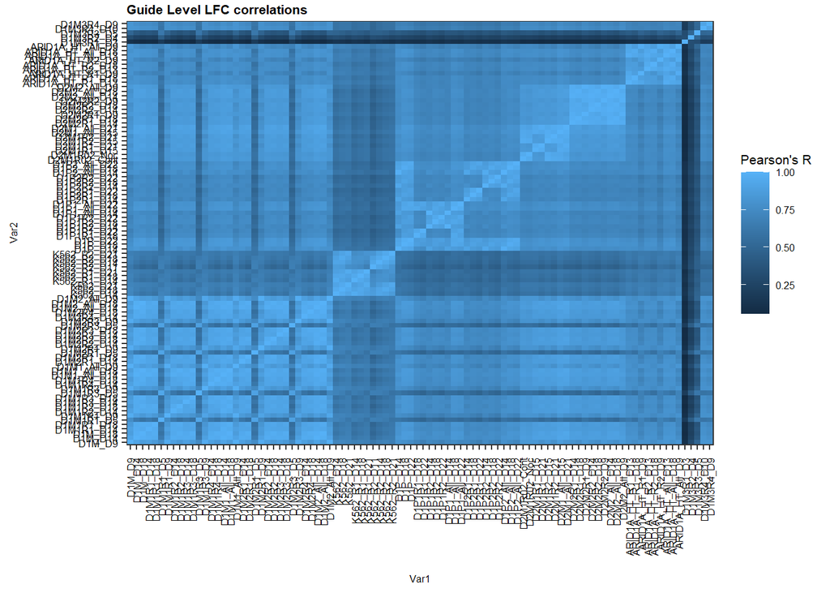

```r
melted_cormat<- melted_cormat %>%  arrange(Var1)

supp_fig_3_b<-ggplot(data = melted_cormat, aes(x=Var1, y=Var2, fill=value)) +
  geom_tile() +theme_su()+ theme(axis.text.x = element_text(angle = 90, vjust = 0.5, hjust=1)) + ggtitle("Guide Level LFC correlations")+scale_fill_continuous(name="Pearson's R")
supp_fig_3_b
```

```r
ggsave(supp_fig_3_b, filename ="E:/Paper writing/CRIPSRi paper/Analyses/plots/panel_3/supp_fig_3_b.svg", width = 6, height = 5, units = "in", dpi = 1000)
```

##correlation plot focusing only final time points

```r
final_screens<- all_dolcetto_LFC %>% select(1:3, contains(c("D18", "D21", "D22")))
names(final_screens)
```

```
##  [1] "Guide.Sequence"    "Gene"              "func"
##  [4] "D1M_D18"           "D1M1R1_D18"        "D1M1R2_D18"
##  [7] "D1M1R3_D18"        "D1M1R4_D18"        "D1M1_All_D18"
## [10] "D1M2R1_D18"        "D1M2R2_D18"        "D1M2R3_D18"
## [13] "D1M2R4_D18"        "D1M2_All_D18"      "K562_D18"
## [16] "K562_R1_D18"       "K562_R2_D18"       "D1P_D18"
## [19] "D1P1R1_D18"        "D1P1R2_D18"        "D1P1_All_D18"
## [22] "D1P2R1_D18"        "D1P2R2_D18"        "D1P2_All_D18"
## [25] "D2M2R1_D18"        "D2M2R2_D18"        "D2M2_All_D18"
## [28] "ARID1A_HT_R1_D18"  "ARID1A_HT_R2_D18"  "ARID1A_HT_All_D18"
## [31] "K562_D21"          "K562_R1_D21"       "K562_R2_D21"
## [34] "D2M1R1_D21"        "D2M1R2_D21"        "D2M1_All_D21"
## [37] "D1P_D22"           "D1P1R1_D22"        "D1P1R2_D22"
## [40] "D1P1_All_D22"      "D1P2R1_D22"        "D1P2R2_D22"
## [43] "D1P2_All_D22"
```

```r
cormat2<- round(cor(final_screens[,4:43], method = "pearson"),3)

melted_cormat2 <- melt(cormat2)
head(melted_cormat2)
```

|  | Var1 | Var2 | value |
| --- | --- | --- | --- |
| 1 | D1M_D18 | D1M_D18 | 1.000 |
| 2 | D1M1R1_D18 | D1M_D18 | 0.973 |
| 3 | D1M1R2_D18 | D1M_D18 | 0.973 |
| 4 | D1M1R3_D18 | D1M_D18 | 0.975 |
| 5 | D1M1R4_D18 | D1M_D18 | 0.973 |
| 6 | D1M1_All_D18 | D1M_D18 | 0.994 |

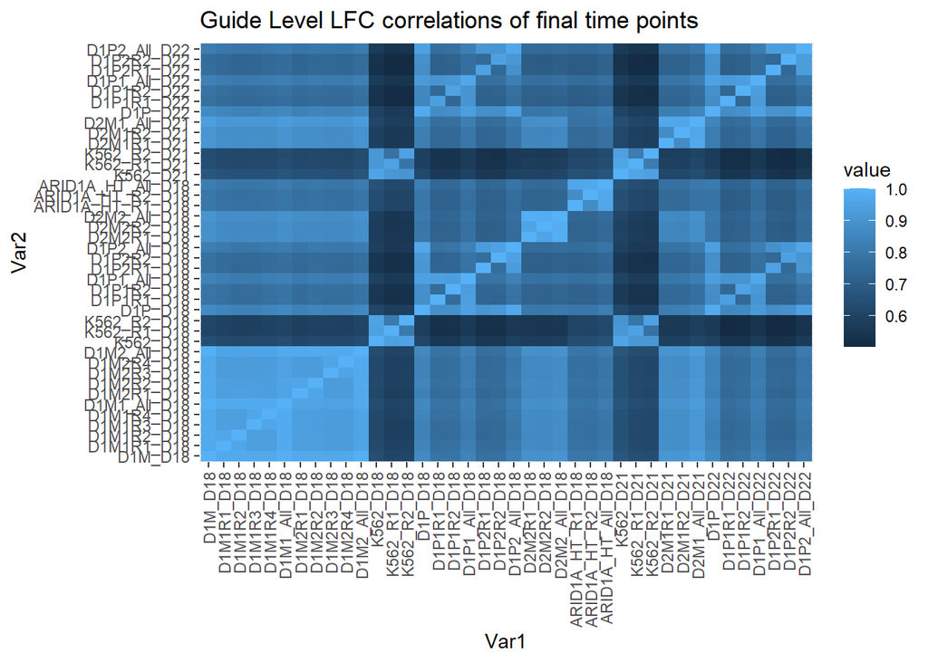

```r
melted_cormat2<- melted_cormat2 %>%  arrange(Var1)

ggplot(data = melted_cormat2, aes(x=Var1, y=Var2, fill=value)) +
  geom_tile() + theme(axis.text.x = element_text(angle = 90, vjust = 0.5, hjust=1)) + ggtitle("Guide Level LFC correlations of final time points")
```

##correlation_plot of monoclonal IPSC and K562 cells final time point

```r
ipsc_k562_final<- final_screens %>% select(1:3, contains(c("D1M","D2M")), K562_D21, K562_R1_D21, K562_R2_D21)
names(ipsc_k562_final)<- gsub(x=names(ipsc_k562_final),pattern = "_D.*", replacement = "")
names(ipsc_k562_final)
```

```
##  [1] "Guide.Sequence" "Gene"           "func"           "D1M"
##  [5] "D1M1R1"         "D1M1R2"         "D1M1R3"         "D1M1R4"
##  [9] "D1M1_All"       "D1M2R1"         "D1M2R2"         "D1M2R3"
## [13] "D1M2R4"         "D1M2_All"       "D2M2R1"         "D2M2R2"
## [17] "D2M2_All"       "D2M1R1"         "D2M1R2"         "D2M1_All"
## [21] "K562"           "K562_R1"        "K562_R2"
```

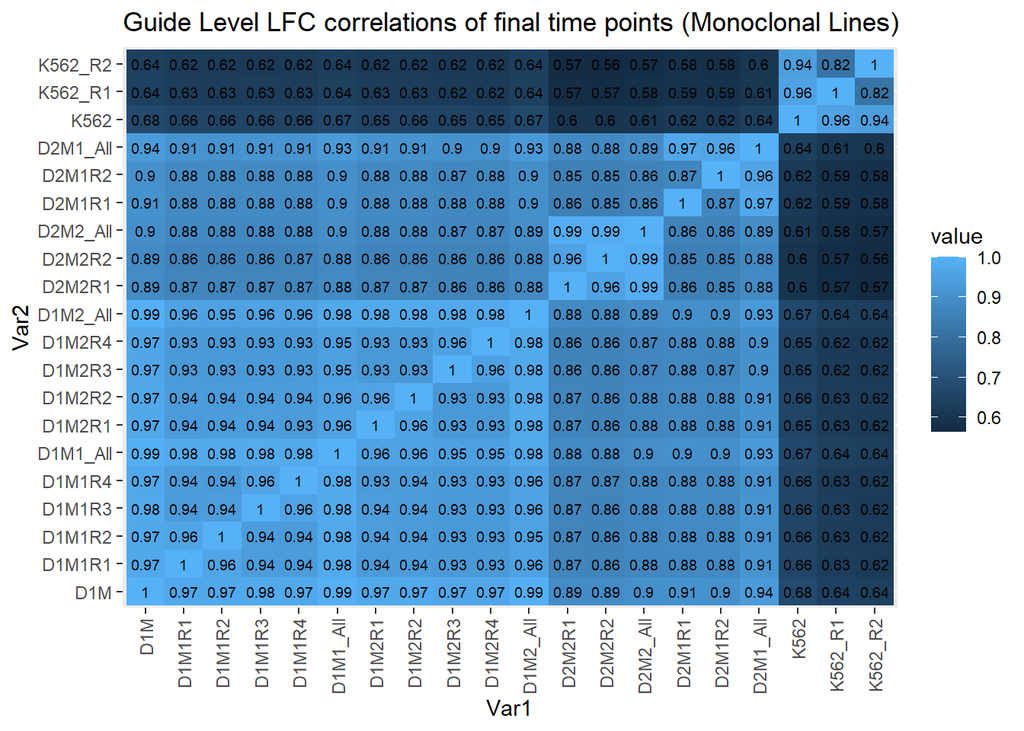

```r
cormat3<- round(cor(ipsc_k562_final[,4:length(ipsc_k562_final)], method = "pearson"),3)


melted_cormat3 <- melt(cormat3)

melted_cormat3<- melted_cormat3 %>%  arrange(Var1)

ggplot(data = melted_cormat3, aes(x=Var1, y=Var2, fill=value)) +
  geom_tile() + theme(axis.text.x = element_text(angle = 90, vjust = 0.5, hjust=1)) + ggtitle("Guide Level LFC correlations of final time points (Monoclonal Lines)") +geom_text(aes(label = round(value, 2)), size=2.5)
```

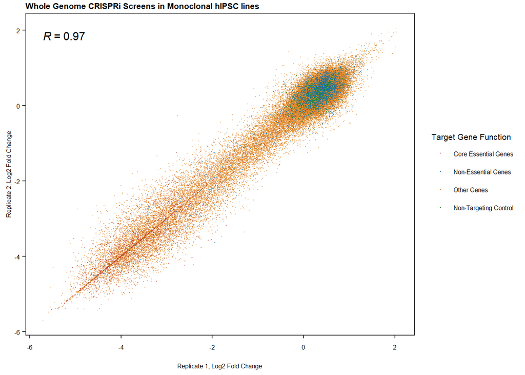

```r
library(ggpubr)

library(cowplot)

scatter1<-
ggplot()+geom_point(data=(ipsc_k562_final %>% filter(func=="Other")),aes(x=D1M1_All, y=D1M2_All, color=func), size=0.05, alpha=0.5)+geom_point(data=(ipsc_k562_final %>% filter(func!="Other")),aes(x=D1M1_All, y=D1M2_All, color=func), size=0.05, alpha=0.5)+geom_point(data=(ipsc_k562_final %>% filter(func=="CONTROL")),aes(x=D1M1_All, y=D1M2_All, color=func), size=0.05, alpha=0.5)+stat_cor(inherit.aes = F, data=ipsc_k562_final, aes(x=D1M1_All, y=D1M2_All, label = ..r.label..))+ scale_color_manual(name="Target Gene Function",limits=c("CEG", "NEG", "Other", "CONTROL"),labels=c("CEG"="Core Essential Genes" , "NEG"="Non-Essential Genes",  "CONTROL"="Non-Targeting Control", "Other"="Other Genes"), values=c("CEG"="#BC3C29FF" , "NEG"="#0072B5FF",  "CONTROL"="forestgreen", "Other"="#E18727FF" ))+ xlab("Replicate 1, Log2 Fold Change")+ ylab("Replicate 2, Log2 Fold Change")+ ggtitle("Whole Genome CRISPRi Screens in Monoclonal hIPSC lines")+theme_su()
scatter1
```

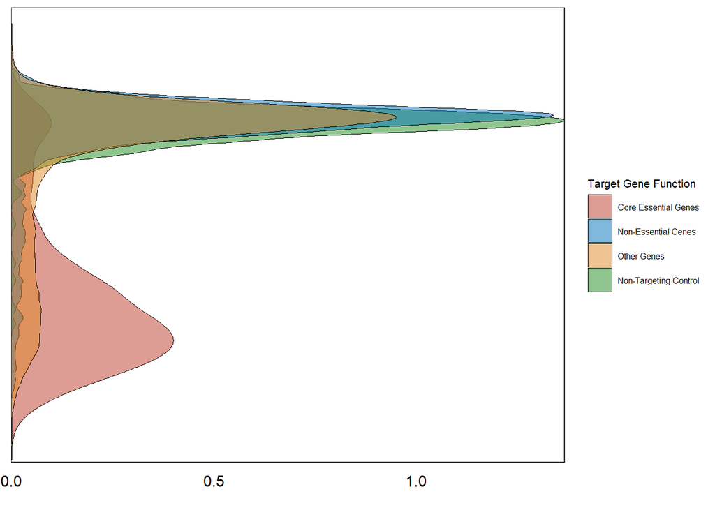

```r
ydens <- axis_canvas(scatter1, axis = "y", coord_flip = T)+  geom_density(data = ipsc_k562_final, aes( x=D1M1_All, fill=func),alpha = 0.5, size = 0.2)+ scale_fill_manual(name="Target Gene Function",limits=c("CEG", "NEG", "Other", "CONTROL"),labels=c("CEG"="Core Essential Genes" , "NEG"="Non-Essential Genes",  "CONTROL"="Non-Targeting Control", "Other"="Other Genes"), values=c("CEG"="#BC3C29FF" , "NEG"="#0072B5FF",  "CONTROL"="forestgreen", "Other"="#E18727FF" ))+ theme_su()+theme(axis.title = element_blank(), axis.text =  element_blank(), axis.ticks =  element_blank())+coord_flip()
ydens
```

```r
p1 <- insert_yaxis_grob(scatter1, ydens, grid::unit(.2, "null"), position = "right")
```

[output not shown]

[output not shown]

[output not shown]

[output cut: 220 more lines]

[output not shown]

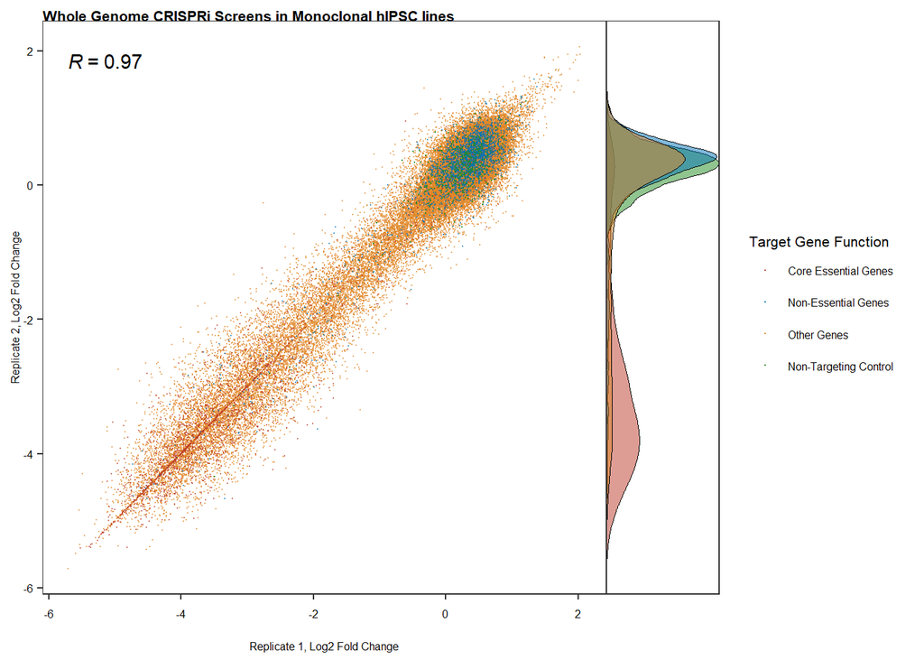

```r
figure_3_b<- ggdraw(p1)
figure_3_b
```

```r
ggsave(figure_3_b, filename = "E:/Paper writing/CRIPSRi paper/Analyses/plots/panel_3/fig_3_b.svg", width = 4, height = 2.5, units = "in", dpi=1000)
```

#produce same plot for K562 screens:

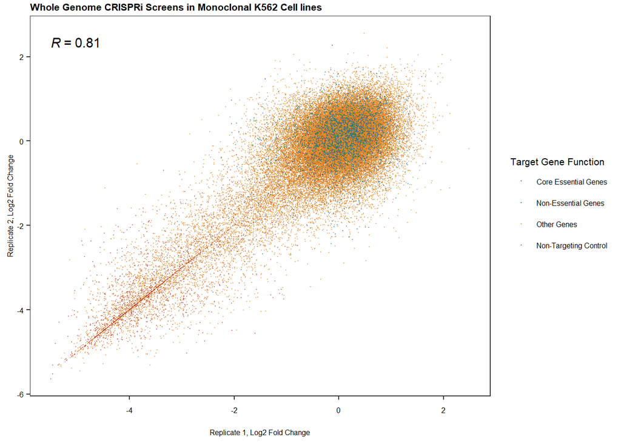

```r
scatter2<-
ggplot()+geom_point(data=(ipsc_k562_final %>% filter(func=="Other")),aes(x=K562_R1, y=K562_R2, color=func), size=0.05, alpha=0.5)+geom_point(data=(ipsc_k562_final %>% filter(func!="Other")),aes(x=K562_R1, y=K562_R2, color=func), size=0.05, alpha=0.5)+geom_point(data=(ipsc_k562_final %>% filter(func=="CONTROL")),aes(x=K562_R1, y=K562_R2, color=func), alpha=0.5, size=0.05)+stat_cor(inherit.aes = F, data=ipsc_k562_final, aes(x=K562_R1, y=K562_R2, label = ..r.label..))+ scale_color_manual(name="Target Gene Function",limits=c("CEG", "NEG", "Other", "CONTROL"),labels=c("CEG"="Core Essential Genes" , "NEG"="Non-Essential Genes",  "CONTROL"="Non-Targeting Control", "Other"="Other Genes"), values=c("CEG"="#BC3C29FF" , "NEG"="#0072B5FF",  "CONTROL"="forestgreen", "Other"="#E18727FF" ))+ xlab("Replicate 1, Log2 Fold Change")+ ylab("Replicate 2, Log2 Fold Change")+ ggtitle("Whole Genome CRISPRi Screens in Monoclonal K562 Cell lines")+theme_su()
scatter2
```

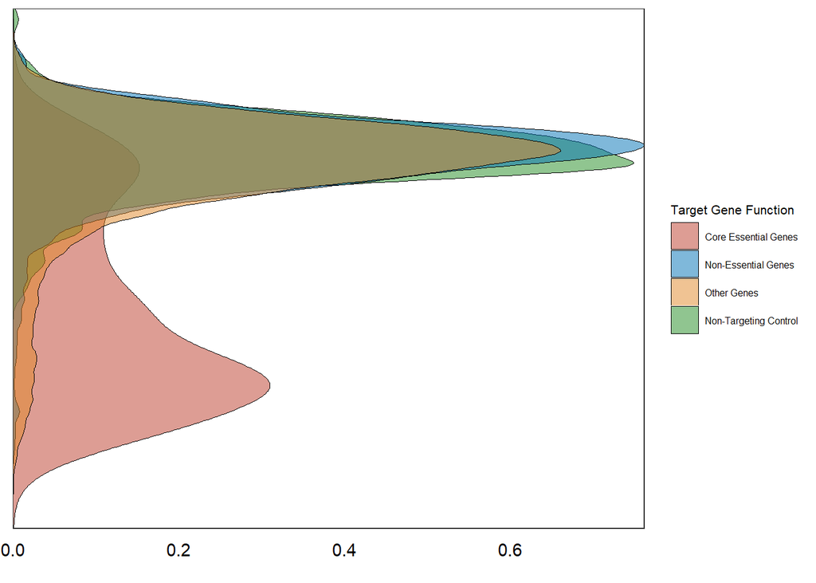

```r
ydens2 <- axis_canvas(scatter1, axis = "y", coord_flip = T)+  geom_density(data = ipsc_k562_final, aes( x=K562_R2,  fill=func),alpha = 0.5, size = 0.2)+ scale_fill_manual(name="Target Gene Function",limits=c("CEG", "NEG", "Other", "CONTROL"),labels=c("CEG"="Core Essential Genes" , "NEG"="Non-Essential Genes",  "CONTROL"="Non-Targeting Control", "Other"="Other Genes"), values=c("CEG"="#BC3C29FF" , "NEG"="#0072B5FF",  "CONTROL"="forestgreen", "Other"="#E18727FF" ))+ theme_su()+theme(axis.title = element_blank(), axis.text =  element_blank(), axis.ticks =  element_blank())+coord_flip()
ydens2
```

```r
p2 <- insert_yaxis_grob(scatter2, ydens2, grid::unit(.2, "null"), position = "right")
```

[output not shown]

[output cut: 256 more lines]

[output not shown]

```r
p2
```

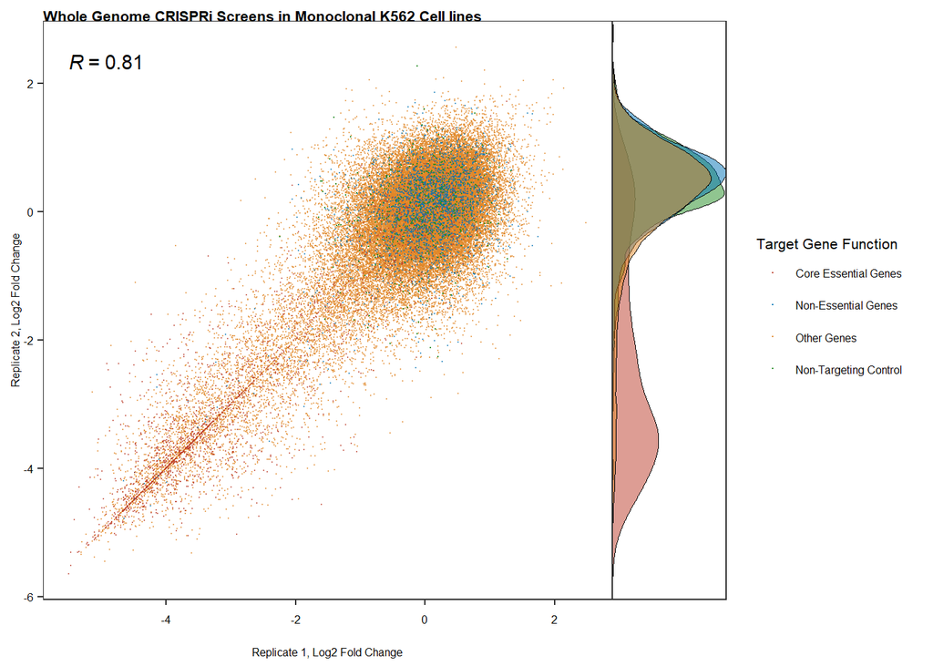

```r
supp_fig_3_c<- ggdraw(p2)
supp_fig_3_c
```

```r
ggsave(supp_fig_3_c, filename = "E:/Paper writing/CRIPSRi paper/Analyses/plots/panel_3/supp_fig_3_c.svg", width = 4, height = 2.5, units = "in", dpi=1000)
```

### Correlation plot for publication

```r
names(final_screens)
```

```
##  [1] "Guide.Sequence"    "Gene"              "func"
##  [4] "D1M_D18"           "D1M1R1_D18"        "D1M1R2_D18"
##  [7] "D1M1R3_D18"        "D1M1R4_D18"        "D1M1_All_D18"
## [10] "D1M2R1_D18"        "D1M2R2_D18"        "D1M2R3_D18"
## [13] "D1M2R4_D18"        "D1M2_All_D18"      "K562_D18"
## [16] "K562_R1_D18"       "K562_R2_D18"       "D1P_D18"
## [19] "D1P1R1_D18"        "D1P1R2_D18"        "D1P1_All_D18"
## [22] "D1P2R1_D18"        "D1P2R2_D18"        "D1P2_All_D18"
## [25] "D2M2R1_D18"        "D2M2R2_D18"        "D2M2_All_D18"
## [28] "ARID1A_HT_R1_D18"  "ARID1A_HT_R2_D18"  "ARID1A_HT_All_D18"
## [31] "K562_D21"          "K562_R1_D21"       "K562_R2_D21"
## [34] "D2M1R1_D21"        "D2M1R2_D21"        "D2M1_All_D21"
## [37] "D1P_D22"           "D1P1R1_D22"        "D1P1R2_D22"
## [40] "D1P1_All_D22"      "D1P2R1_D22"        "D1P2R2_D22"
## [43] "D1P2_All_D22"
```

```r
selected<- final_screens %>% select(1:3,D1P_D22, D1P1_All_D22, D1P2_All_D22, D1M1R1_D18, D1M1R2_D18, D1M1_All_D18,D1M2_All_D18, D1M_D18,D2M1_All_D21, D2M2_All_D18)
names(selected)
```

```
##  [1] "Guide.Sequence" "Gene"           "func"           "D1P_D22"
##  [5] "D1P1_All_D22"   "D1P2_All_D22"   "D1M1R1_D18"     "D1M1R2_D18"
##  [9] "D1M1_All_D18"   "D1M2_All_D18"   "D1M_D18"        "D2M1_All_D21"
## [13] "D2M2_All_D18"
```

```r
cormat4<- round(cor(selected[,4:13], method = "pearson"),3)

melted_cormat4 <- melt(cormat4)

melted_cormat4<- melted_cormat4 %>%  arrange(Var1)



levels(melted_cormat4$Var1)
```

```
##  [1] "D1P_D22"      "D1P1_All_D22" "D1P2_All_D22" "D1M1R1_D18"   "D1M1R2_D18"
##  [6] "D1M1_All_D18" "D1M2_All_D18" "D1M_D18"      "D2M1_All_D21" "D2M2_All_D18"
```

[output not shown]

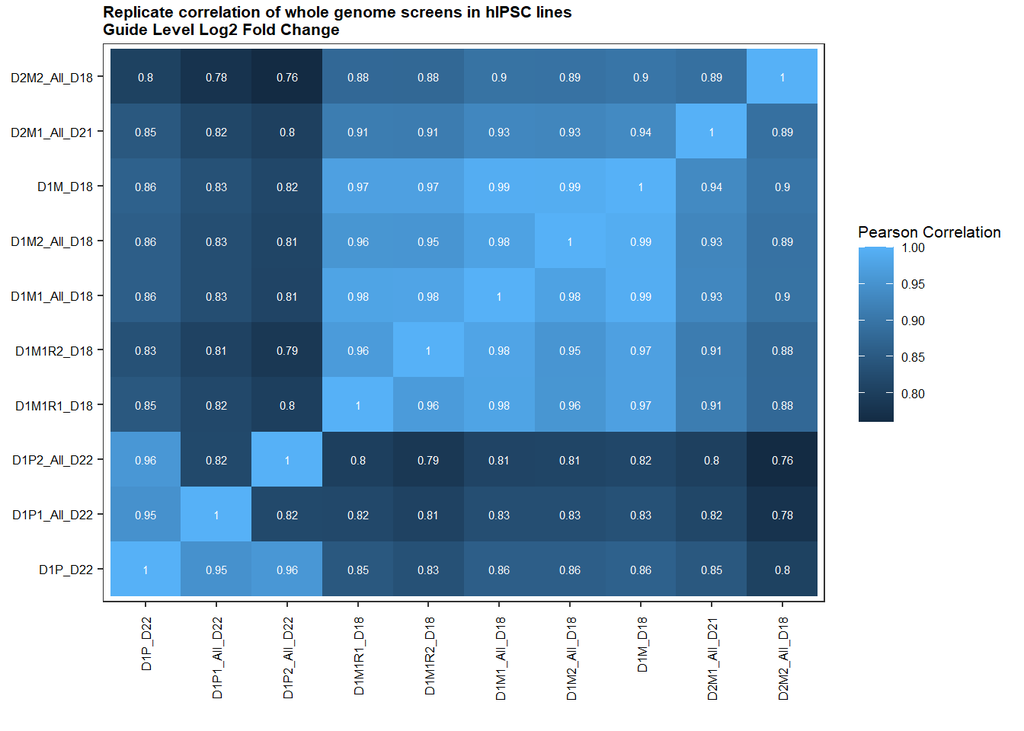

```r
supp_fig_3_d<-ggplot(data = melted_cormat4, aes(x=Var1, y=Var2, fill=value)) +  geom_tile() +theme_su()+ theme(axis.text.x = element_text(angle = 90, vjust = 0.5, hjust=1)) + ggtitle("Replicate correlation of whole genome screens in hIPSC lines\nGuide Level Log2 Fold Change") +geom_text(aes(label = round(value, 2)), size=2, color="white") +theme(axis.title = element_blank())+ scale_fill_gradient(name="Pearson Correlation")
supp_fig_3_d
```

```r
ggsave(supp_fig_3_d, filename = "E:/Paper writing/CRIPSRi paper/Analyses/plots/panel_3/supp_fig_3_d.svg", units = "in", width = 5, height = 4)
```

### Calculate Gene Mean Log2 Fold Change

```r
all_dolcetto_LFC_Gene<- all_dolcetto_LFC %>% select(2:97) %>%  group_by(Gene, func) %>%
  summarise(across(
    .cols = where(is.numeric),
    .fns = list(Mean = mean), na.rm = TRUE,
    .names = "{col}"
  )) %>% filter(func !="CONTROL") %>% droplevels()
write_csv(all_dolcetto_LFC_Gene, file="output/all_dolcetto_LFC_Gene.txt")
```

```r
all_dolcetto_LFC_Gene<- read_csv(file="output/all_dolcetto_LFC_Gene.txt")
names(all_dolcetto_LFC_Gene)
```

```
##  [1] "Gene"              "func"              "D1M_D9"
##  [4] "D1M_D14"           "D1M_D18"           "D1M1R1_D14"
##  [7] "D1M1R1_D18"        "D1M1R1_D5"         "D1M1R1_D9"
## [10] "D1M1R2_D14"        "D1M1R2_D18"        "D1M1R3_D14"
## [13] "D1M1R3_D18"        "D1M1R3_D5"         "D1M1R3_D9"
## [16] "D1M1R4_D14"        "D1M1R4_D18"        "D1M1_All_D14"
## [19] "D1M1_All_D18"      "D1M1_All_D9"       "D1M2R1_D14"
## [22] "D1M2R1_D18"        "D1M2R1_D5"         "D1M2R1_D9"
## [25] "D1M2R2_D14"        "D1M2R2_D18"        "D1M2R3_D14"
## [28] "D1M2R3_D18"        "D1M2R3_D5"         "D1M2R3_D9"
## [31] "D1M2R4_D14"        "D1M2R4_D18"        "D1M2_All_D14"
## [34] "D1M2_All_D18"      "D1M2_All_D9"       "K562_D14"
## [37] "K562_D18"          "K562_D21"          "K562_R1_D14"
## [40] "K562_R1_D18"       "K562_R1_D21"       "K562_R2_D11"
## [43] "K562_R2_D14"       "K562_R2_D18"       "K562_R2_D21"
```

[output cut: 17 more lines]

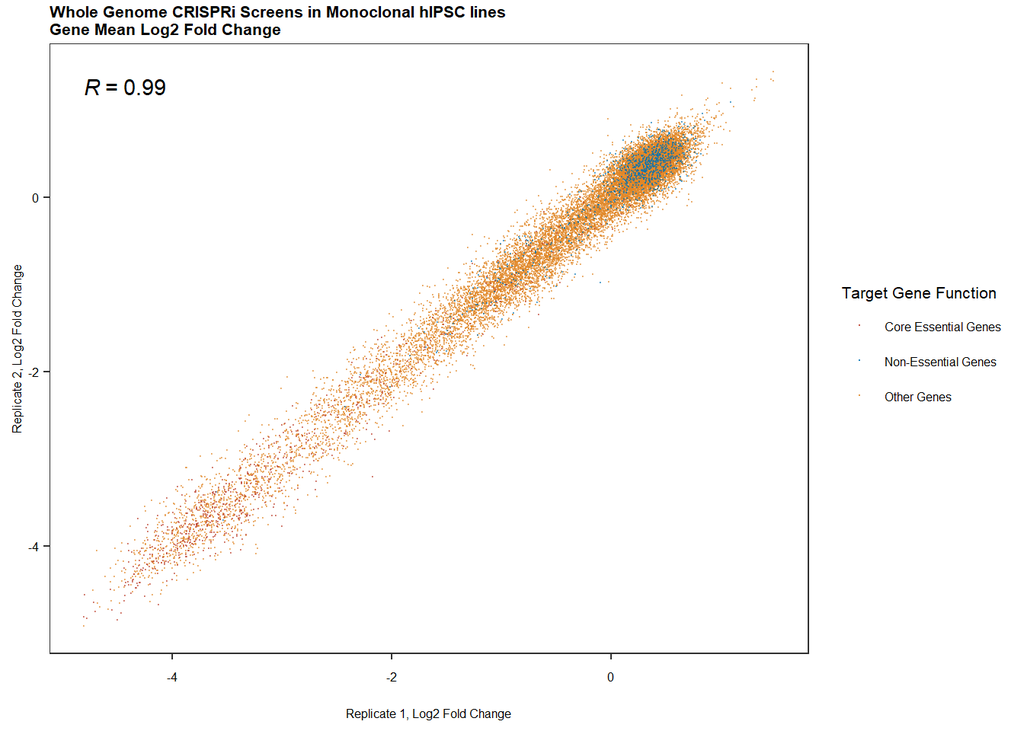

```r
supp_fig_3_e<- ggplot()+geom_point(data=(all_dolcetto_LFC_Gene %>% filter(func=="Other")),aes(x=D1M1_All_D18, y=D1M2_All_D18, color=func), size=0.05, alpha=0.5)+geom_point(data=(all_dolcetto_LFC_Gene %>% filter(func!="Other")),aes(x=D1M1_All_D18, y=D1M2_All_D18, color=func), size=0.05, alpha=0.5)+stat_cor(inherit.aes = F, data=all_dolcetto_LFC_Gene, aes(x=D1M1_All_D18, y=D1M2_All_D18, label = ..r.label..))+ scale_color_manual(name="Target Gene Function",limits=c("CEG", "NEG", "Other"),labels=c("CEG"="Core Essential Genes" , "NEG"="Non-Essential Genes", "Other"="Other Genes"), values=c("CEG"="#BC3C29FF" , "NEG"="#0072B5FF", "Other"="#E18727FF" ))+ xlab("Replicate 1, Log2 Fold Change")+ ylab("Replicate 2, Log2 Fold Change")+ ggtitle("Whole Genome CRISPRi Screens in Monoclonal hIPSC lines\nGene Mean Log2 Fold Change")+theme_su()
supp_fig_3_e
```

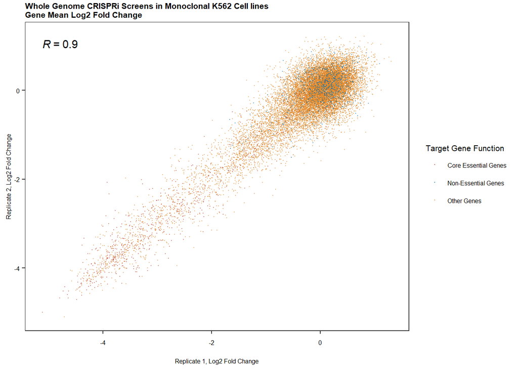

```r
ggsave(supp_fig_3_e, filename = "E:/Paper writing/CRIPSRi paper/Analyses/plots/panel_3/supp_fig_3_e.svg", units = "in", width = 5, height = 4,dpi=1000)

supp_fig_3_f<-ggplot()+geom_point(data=(all_dolcetto_LFC_Gene %>% filter(func=="Other")),aes(x=K562_R1_D21, y=K562_R2_D21, color=func), size=0.05, alpha=0.5)+geom_point(data=(all_dolcetto_LFC_Gene %>% filter(func!="Other")),aes(x=K562_R1_D21, y=K562_R2_D21, color=func), size=0.05, alpha=0.5)+stat_cor(inherit.aes = F, data=all_dolcetto_LFC_Gene, aes(x=K562_R1_D21, y=K562_R2_D21, label = ..r.label..))+ scale_color_manual(name="Target Gene Function",limits=c("CEG", "NEG", "Other"),labels=c("CEG"="Core Essential Genes" , "NEG"="Non-Essential Genes", "Other"="Other Genes"), values=c("CEG"="#BC3C29FF" , "NEG"="#0072B5FF", "Other"="#E18727FF" ))+ xlab("Replicate 1, Log2 Fold Change")+ ylab("Replicate 2, Log2 Fold Change")+ ggtitle("Whole Genome CRISPRi Screens in Monoclonal K562 Cell lines\nGene Mean Log2 Fold Change")+theme_su()
supp_fig_3_f
```

```r
ggsave(supp_fig_3_f, filename = "E:/Paper writing/CRIPSRi paper/Analyses/plots/panel_3/supp_fig_3_f.svg", units = "in", width = 5, height = 4, dpi=1000)
```

## Gene mean LFC correlation plot

[output not shown]

[output cut: 19 more lines]

[output not shown]

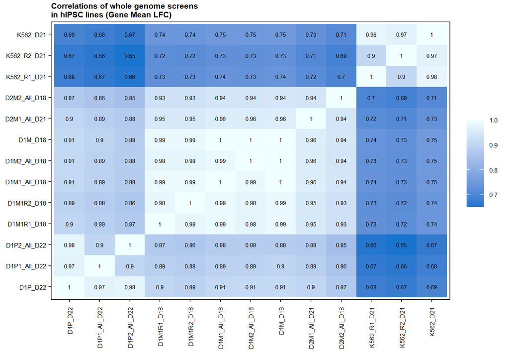

```r
selected_gene<- all_dolcetto_LFC_Gene %>% select(1:2,D1P_D22, D1P1_All_D22, D1P2_All_D22, D1M1R1_D18, D1M1R2_D18, D1M1_All_D18,D1M2_All_D18, D1M_D18,D2M1_All_D21, D2M2_All_D18, K562_R1_D21, K562_R2_D21, K562_D21)


cormat5<- round(cor(selected_gene[,3:15], method = "pearson"),3)

melted_cormat5 <- melt(cormat5)

melted_cormat5<- melted_cormat5 %>%  arrange(Var1)

figure_3_c<-ggplot(data = melted_cormat5, aes(x=Var1, y=Var2, fill=value)) +
  geom_tile() +theme_su()+ theme(axis.text.x = element_text(angle = 90, vjust = 0.5, hjust=1), axis.title = element_blank(), legend.title = element_blank()) + ggtitle("Correlations of whole genome screens \nin hIPSC lines (Gene Mean LFC)") +geom_text(aes(label = round(value, 2)), size=2, color="Black") + scale_fill_gradient(name="Gene Mean LFC \nPearson Correlations", low = "#1874CD", high = "Azure")
figure_3_c
```

```r
ggsave(figure_3_c,  filename = "E:/Paper writing/CRIPSRi paper/Analyses/plots/panel_3/fig_3_c_new.svg", units = "in", width = 4, height = 2.5, dpi=1000)
```

### calculate time dependent depletion

```r
a<- all_dolcetto_LFC_Gene
a$D1M_D5<- (a$D1M1R1_D5+ a$D1M1R3_D5+ a$D1M2R1_D5+ a$D1M2R3_D5)/4
names(a)
```

```
##  [1] "Gene"              "func"              "D1M_D9"
##  [4] "D1M_D14"           "D1M_D18"           "D1M1R1_D14"
##  [7] "D1M1R1_D18"        "D1M1R1_D5"         "D1M1R1_D9"
## [10] "D1M1R2_D14"        "D1M1R2_D18"        "D1M1R3_D14"
## [13] "D1M1R3_D18"        "D1M1R3_D5"         "D1M1R3_D9"
## [16] "D1M1R4_D14"        "D1M1R4_D18"        "D1M1_All_D14"
## [19] "D1M1_All_D18"      "D1M1_All_D9"       "D1M2R1_D14"
## [22] "D1M2R1_D18"        "D1M2R1_D5"         "D1M2R1_D9"
## [25] "D1M2R2_D14"        "D1M2R2_D18"        "D1M2R3_D14"
## [28] "D1M2R3_D18"        "D1M2R3_D5"         "D1M2R3_D9"
## [31] "D1M2R4_D14"        "D1M2R4_D18"        "D1M2_All_D14"
## [34] "D1M2_All_D18"      "D1M2_All_D9"       "K562_D14"
## [37] "K562_D18"          "K562_D21"          "K562_R1_D14"
## [40] "K562_R1_D18"       "K562_R1_D21"       "K562_R2_D11"
## [43] "K562_R2_D14"       "K562_R2_D18"       "K562_R2_D21"
```

[output cut: 18 more lines]

```r
a <-a %>% select(Gene, func, contains(c("D1M_","K562_D", "D1M3")))


time_analysis<- melt(a)
time_analysis<- time_analysis %>% separate(variable, into = c("Screen", "time"), sep = "_D")
time_analysis<- time_analysis %>% mutate(Screen=case_when(
  Screen=="D1M" ~"IPSC",
  grepl('D1M3', Screen)  ~ "Prescreen",
     TRUE ~ as.character(Screen)))
time_analysis<- do.call("data.frame", time_analysis)

levels(time_analysis$Screen)
```

```
## [1] "IPSC"      "K562"      "Prescreen"
```

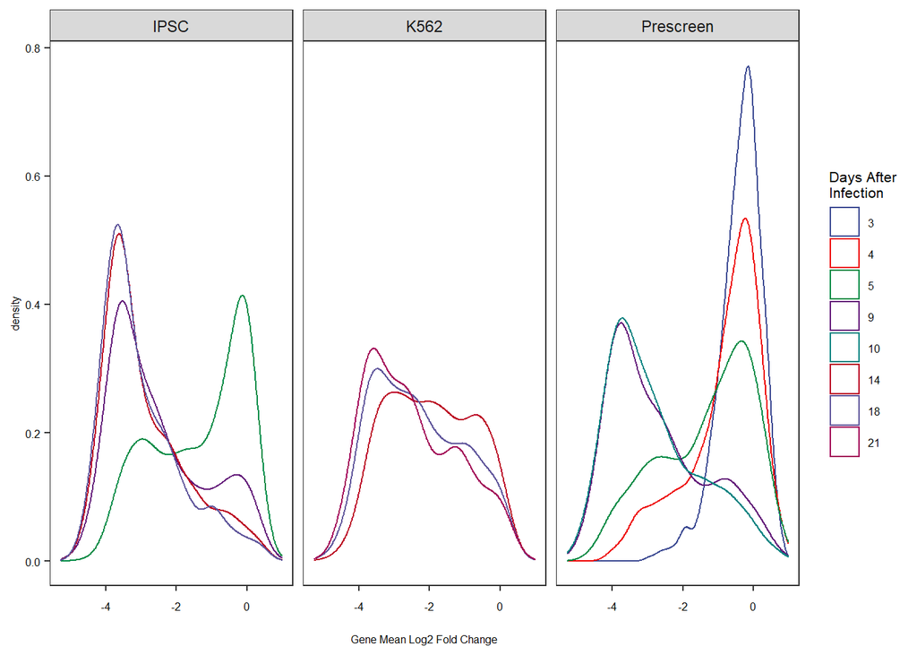

```r
level_order <- c("3","4","5","9","10","14", "18", "21","22")

supp_fig_3_g<- time_analysis %>% filter(func=="CEG") %>% ggplot(aes(x=value, color=factor(time,level=level_order)))+ geom_density()+facet_grid(~Screen)+theme_su()+xlab("Gene Mean Log2 Fold Change")+scale_color_aaas(name="Days After\nInfection")
supp_fig_3_g
```

```r
ggsave(supp_fig_3_g,  filename = "E:/Paper writing/CRIPSRi paper/Analyses/plots/panel_3/supp_fig_3_g.svg", units = "in", width = 4, height = 2.5, dpi=1000)
```

### calculate ROC curve and AUC values:

```r
all_dolcetto_LFC_Gene<- read_csv( file="output/all_dolcetto_LFC_Gene.txt")
gene_NEG_CEG<- all_dolcetto_LFC_Gene %>% filter(func=="CEG"|func=="NEG")


gene_NEG_CEG <- gene_NEG_CEG %>% mutate(ess=case_when(
  func== "CEG" ~1,
  func=="NEG"~ 0
))
gene_NEG_CEG<- do.call("data.frame",gene_NEG_CEG)


b<- list()
names(gene_NEG_CEG)
```

```
##  [1] "Gene"              "func"              "D1M_D9"
##  [4] "D1M_D14"           "D1M_D18"           "D1M1R1_D14"
##  [7] "D1M1R1_D18"        "D1M1R1_D5"         "D1M1R1_D9"
## [10] "D1M1R2_D14"        "D1M1R2_D18"        "D1M1R3_D14"
## [13] "D1M1R3_D18"        "D1M1R3_D5"         "D1M1R3_D9"
## [16] "D1M1R4_D14"        "D1M1R4_D18"        "D1M1_All_D14"
## [19] "D1M1_All_D18"      "D1M1_All_D9"       "D1M2R1_D14"
## [22] "D1M2R1_D18"        "D1M2R1_D5"         "D1M2R1_D9"
## [25] "D1M2R2_D14"        "D1M2R2_D18"        "D1M2R3_D14"
## [28] "D1M2R3_D18"        "D1M2R3_D5"         "D1M2R3_D9"
## [31] "D1M2R4_D14"        "D1M2R4_D18"        "D1M2_All_D14"
## [34] "D1M2_All_D18"      "D1M2_All_D9"       "K562_D14"
## [37] "K562_D18"          "K562_D21"          "K562_R1_D14"
## [40] "K562_R1_D18"       "K562_R1_D21"       "K562_R2_D11"
## [43] "K562_R2_D14"       "K562_R2_D18"       "K562_R2_D21"
```

[output cut: 18 more lines]

```r
names<- names(gene_NEG_CEG[,3:97])
names
```

```
##  [1] "D1M_D9"            "D1M_D14"           "D1M_D18"
##  [4] "D1M1R1_D14"        "D1M1R1_D18"        "D1M1R1_D5"
##  [7] "D1M1R1_D9"         "D1M1R2_D14"        "D1M1R2_D18"
## [10] "D1M1R3_D14"        "D1M1R3_D18"        "D1M1R3_D5"
## [13] "D1M1R3_D9"         "D1M1R4_D14"        "D1M1R4_D18"
## [16] "D1M1_All_D14"      "D1M1_All_D18"      "D1M1_All_D9"
## [19] "D1M2R1_D14"        "D1M2R1_D18"        "D1M2R1_D5"
## [22] "D1M2R1_D9"         "D1M2R2_D14"        "D1M2R2_D18"
## [25] "D1M2R3_D14"        "D1M2R3_D18"        "D1M2R3_D5"
## [28] "D1M2R3_D9"         "D1M2R4_D14"        "D1M2R4_D18"
## [31] "D1M2_All_D14"      "D1M2_All_D18"      "D1M2_All_D9"
## [34] "K562_D14"          "K562_D18"          "K562_D21"
## [37] "K562_R1_D14"       "K562_R1_D18"       "K562_R1_D21"
## [40] "K562_R2_D11"       "K562_R2_D14"       "K562_R2_D18"
## [43] "K562_R2_D21"       "D1P_D14"           "D1P_D18"
```

[output cut: 17 more lines]

```r
index<- c(1:95)
for (i in index){
  b[[names[i]]] <- roc(ess ~ gene_NEG_CEG[,i+2], data=gene_NEG_CEG)
}
```

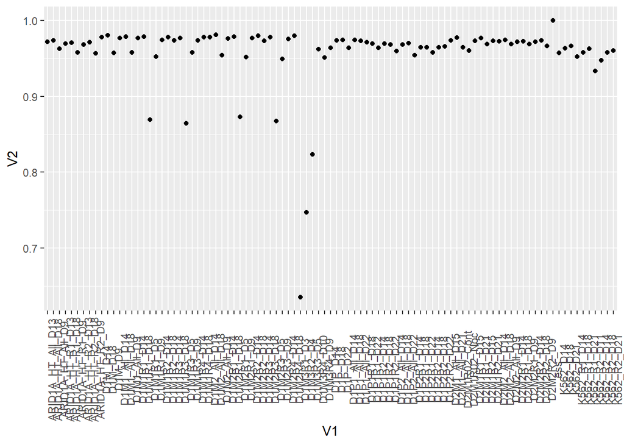

```r
d<- as.data.frame(matrix(nrow = 95, ncol = 2))

for (i in index){
  d[i,1]<-names[i]
  d[i,2]<- b[[i]][["auc"]] }
d %>% ggplot(aes(x=V1, y=V2))+geom_point()+ theme(axis.text.x = element_text(angle=90))
```

```r
all_screens_auc<-d
write_csv(all_screens_auc, file="output/all_screen_auc.txt")
```

```r
m<- all_screens_auc %>% separate(V1, into = c("Screen", "Time"), sep="_D")
m<- do.call(data.frame,m)
summary(m$Time)
```

```
##   10   11   13   14   15   18   21   22    3    4    5    9 NA's
##    1    1    3   23    3   27    6    7    1    1    5   14    3
```

```r
m<- m %>% mutate(TP=case_when(
  Time %in% c(3,4,5)~ "Prescreen",
  Time %in% c(9,10,11)~ "TP1",
  Time %in% c(13,14,15)~ "TP2",
  Time %in% c(18,21)~ "TP3",
  Time %in% c(22)~ "TP4"))
m<- do.call("data.frame",m)
levels(m$TP)
```

```
## [1] "Prescreen" "TP1"       "TP2"       "TP3"       "TP4"
```

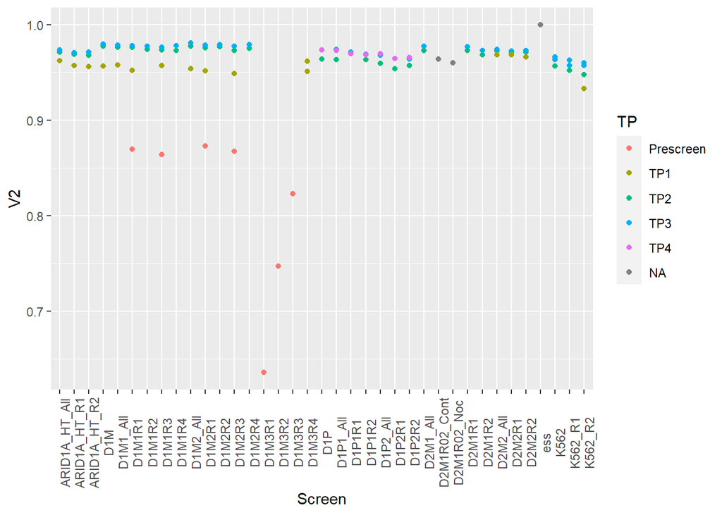

```r
m %>% ggplot(aes(x=Screen, y=V2, color=TP))+geom_point()+theme(axis.text.x = element_text(angle=90))
```

```r
levels(m$Screen)
```

```
##  [1] "ARID1A_HT_All" "ARID1A_HT_R1"  "ARID1A_HT_R2"  "D1M"
##  [5] "D1M1_All"      "D1M1R1"        "D1M1R2"        "D1M1R3"
##  [9] "D1M1R4"        "D1M2_All"      "D1M2R1"        "D1M2R2"
## [13] "D1M2R3"        "D1M2R4"        "D1M3R1"        "D1M3R2"
## [17] "D1M3R3"        "D1M3R4"        "D1P"           "D1P1_All"
## [21] "D1P1R1"        "D1P1R2"        "D1P2_All"      "D1P2R1"
## [25] "D1P2R2"        "D2M1_All"      "D2M1R02_Cont"  "D2M1R02_Noc"
## [29] "D2M1R1"        "D2M1R2"        "D2M2_All"      "D2M2R1"
## [33] "D2M2R2"        "ess"           "K562"          "K562_R1"
## [37] "K562_R2"
```

[output not shown]

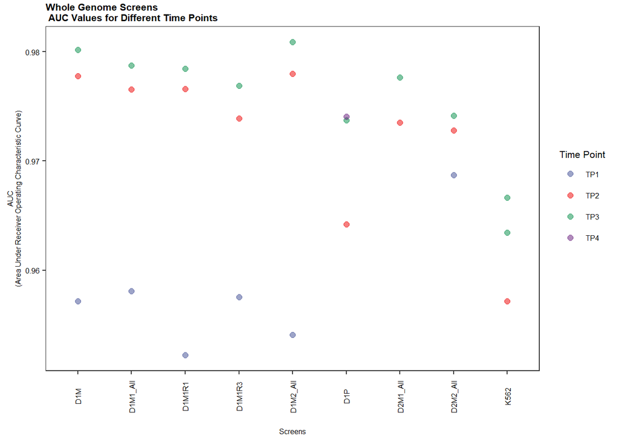

```r
selected_screens<- c(
  "D1M",         "D1M1_All" ,
 "D1M1R1" ,        "D1M1R3",
 "D1M2_All",       "D1P",
 "D2M1_All",       "D2M2_All","K562")

n<- m %>% filter(Screen %in% selected_screens) %>% filter(TP!="Prescreen")

fig_3_e<-n %>% ggplot(aes(x=Screen, y=V2, color=TP))+geom_point(size=2, alpha=0.5)+theme_su()+theme(axis.text.x = element_text(angle=90))+xlab("Screens")+scale_color_aaas(name="Time Point")+ggtitle("Whole Genome Screens\n AUC Values for Different Time Points")+ylab("AUC\n(Area Under Receiver Operating Characteristic Curve)")
fig_3_e
```

```r
ggsave(fig_3_e, filename ="E:/Paper writing/CRIPSRi paper/Analyses/plots/panel_3/fig_3_e_new.svg", units = "in", width = 4, height = 3)
```

ROC curve with final time points

```r
final_roc_data<- all_dolcetto_LFC_Gene %>% select(Gene,func,D1M1=D1M1_All_D18, D1M2=D1M2_All_D18, D1M1R1=D1M1R1_D18, D1M1R2=D1M1R2_D18,D2M1=D2M1_All_D21, D2M2=D2M2_All_D18, D1P1=D1P1_All_D22, D1P2=D1P2_All_D22, K562=K562_D21 )
final_roc_data_NEG_CEG<- final_roc_data%>% filter(func=="CEG"|func=="NEG")


final_roc_data_NEG_CEG <- final_roc_data_NEG_CEG %>% mutate(ess=case_when(
  func== "CEG" ~1,
  func=="NEG"~ 0
))
final_roc_data_NEG_CEG<- do.call("data.frame",final_roc_data_NEG_CEG)


roc_list<- list()
names(final_roc_data_NEG_CEG)
```

```
##  [1] "Gene"   "func"   "D1M1"   "D1M2"   "D1M1R1" "D1M1R2" "D2M1"   "D2M2"
##  [9] "D1P1"   "D1P2"   "K562"   "ess"
```

```r
names<- names(final_roc_data_NEG_CEG[,3:11])
names
```

```
## [1] "D1M1"   "D1M2"   "D1M1R1" "D1M1R2" "D2M1"   "D2M2"   "D1P1"   "D1P2"
## [9] "K562"
```

```r
index<- c(1:9)
for (i in index){
  roc_list[[names[i]]] <- roc(ess ~ final_roc_data_NEG_CEG[,i+2], data=final_roc_data_NEG_CEG)
}
```

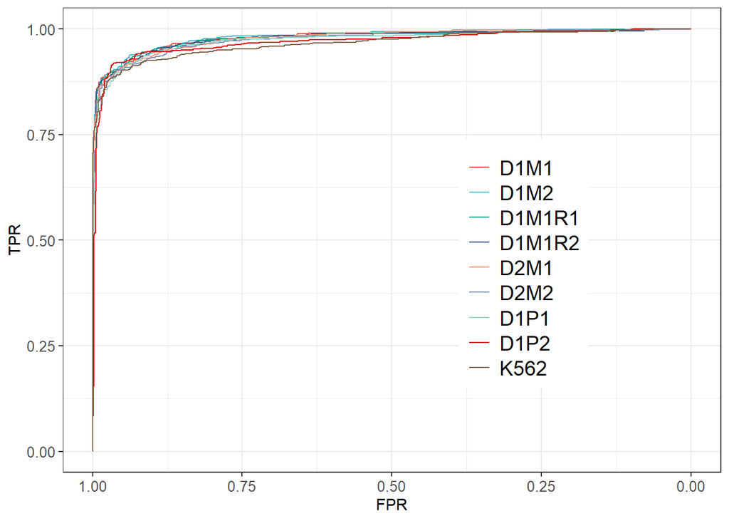

```r
rocfirstplot<- ggroc(roc_list)+
  theme_bw()+xlab("FPR")+ylab("TPR")+theme(axis.text=(element_text(size=10)),legend.title = element_blank(), legend.position=c(.7, 0.45),legend.text=element_text(size =14))+scale_color_npg()
rocfirstplot
```

```r
ggsave(rocfirstplot, filename ="E:/Paper writing/CRIPSRi paper/Analyses/plots/panel_3/fig_3_d_new.svg", units = "in", width = 4, height = 3)
```

###polyclonal vs monoclonal comparison

```r
names(all_dolcetto_LFC_Gene)
```

```
##  [1] "Gene"              "func"              "D1M_D9"
##  [4] "D1M_D14"           "D1M_D18"           "D1M1R1_D14"
##  [7] "D1M1R1_D18"        "D1M1R1_D5"         "D1M1R1_D9"
## [10] "D1M1R2_D14"        "D1M1R2_D18"        "D1M1R3_D14"
## [13] "D1M1R3_D18"        "D1M1R3_D5"         "D1M1R3_D9"
## [16] "D1M1R4_D14"        "D1M1R4_D18"        "D1M1_All_D14"
## [19] "D1M1_All_D18"      "D1M1_All_D9"       "D1M2R1_D14"
## [22] "D1M2R1_D18"        "D1M2R1_D5"         "D1M2R1_D9"
## [25] "D1M2R2_D14"        "D1M2R2_D18"        "D1M2R3_D14"
## [28] "D1M2R3_D18"        "D1M2R3_D5"         "D1M2R3_D9"
## [31] "D1M2R4_D14"        "D1M2R4_D18"        "D1M2_All_D14"
## [34] "D1M2_All_D18"      "D1M2_All_D9"       "K562_D14"
## [37] "K562_D18"          "K562_D21"          "K562_R1_D14"
## [40] "K562_R1_D18"       "K562_R1_D21"       "K562_R2_D11"
## [43] "K562_R2_D14"       "K562_R2_D18"       "K562_R2_D21"
```

[output cut: 17 more lines]

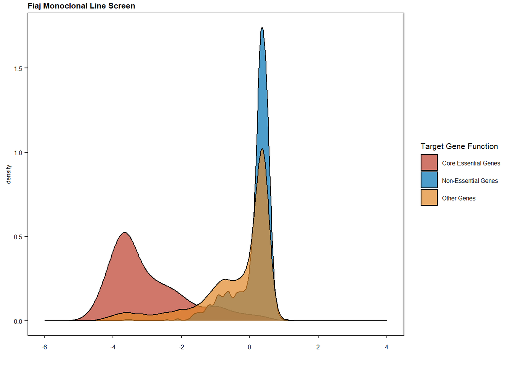

```r
density_poly<-
all_dolcetto_LFC_Gene %>% ggplot()+geom_density(aes(x=D1P_D22, fill=func), alpha=0.7, color="black")+ scale_fill_nejm(name="Target Gene Function",labels=c("CEG"="Core Essential Genes" , "NEG"="Non-Essential Genes",  "CONTROL"="Non-targeting_control", "Other"="Other Genes"))+scale_color_nejm(name="Target Gene Function",labels=c("CEG"="Core Essential Genes" , "NEG"="Non-Essential Genes",  "CONTROL"="Non-targeting_control", "Other"="Other Genes"))+theme_su()+xlim(-6,4)+ xlab("Log2 Fold Change")+ggtitle("Fiaj Polyclonal Line Screen")

density_mono<-
all_dolcetto_LFC_Gene %>% ggplot(aes(x=D1M_D18, fill=func))+geom_density( alpha=0.7, color="black")+ scale_fill_nejm(name="Target Gene Function",labels=c("CEG"="Core Essential Genes" , "NEG"="Non-Essential Genes",  "CONTROL"="Non-targeting_control", "Other"="Other Genes"))+scale_color_nejm(name="Target Gene Function",labels=c("CEG"="Core Essential Genes" , "NEG"="Non-Essential Genes",  "CONTROL"="Non-targeting_control", "Other"="Other Genes"))+theme_su()+xlim(-6,4)+ xlab("Log2 Fold Change")+ggtitle("Fiaj Monoclonal Line Screen")+theme(axis.title.x=element_blank())

supp_fig_3_h<-ggarrange(density_mono, density_poly, ncol=1, common.legend = T, legend = "right")
density_mono
```

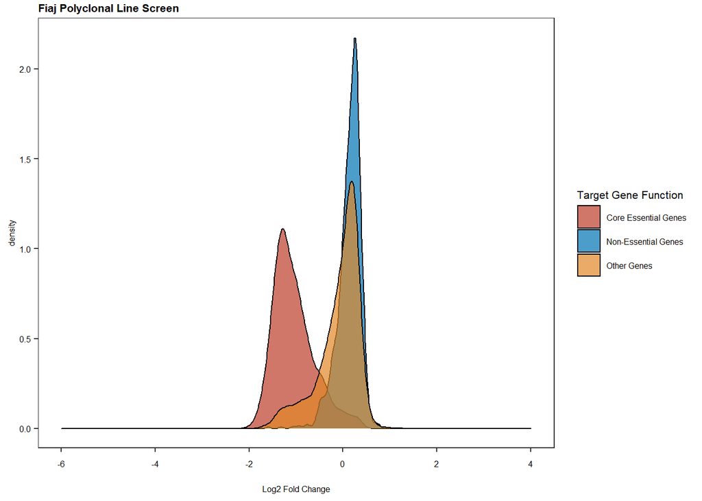

```r
density_poly
```

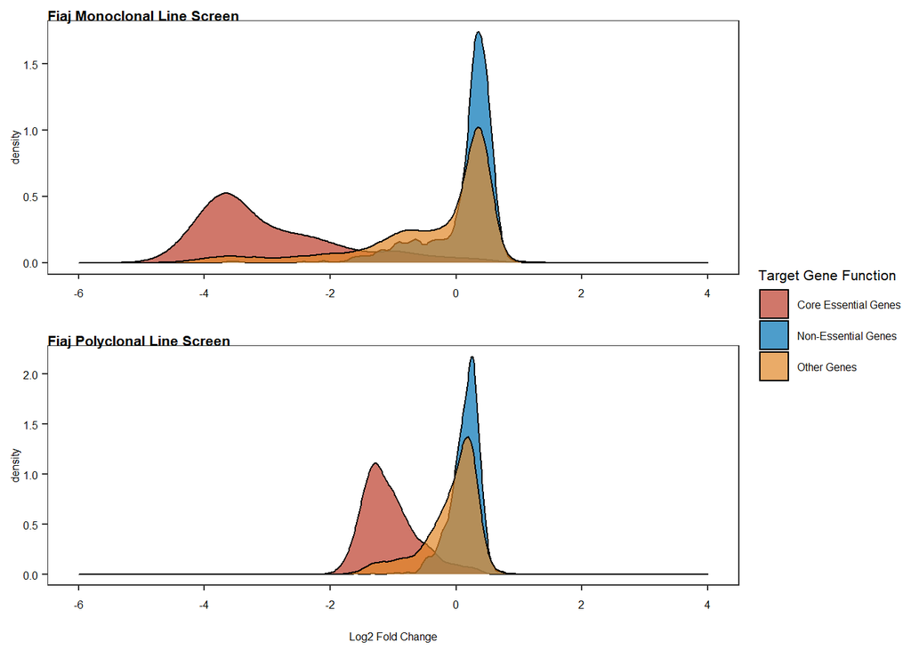

```r
supp_fig_3_h
```

```r
ggsave(supp_fig_3_h, filename ="E:/Paper writing/CRIPSRi paper/Analyses/plots/panel_3/supp_fig_3_h.svg", units = "in", width = 3, height = 3,dpi=1000 )
```